### Classifying quality of exercise using monitor

by Fatima Mouaki 3/22/2015

#### sypnosis

Given both training and test data from the following study:

Velloso, E.; Bulling, A.; Gellersen, H.; Ugulino, W.; Fuks, H. Qualitative Activity Recognition of Weight Lifting Exercises. Proceedings of 4th International Conference in Cooperation with SIGCHI (Augmented Human ’13) . Stuttgart, Germany: ACM SIGCHI, 2013.

the goal of this project is to “predict the manner in which they did the exercise.”

Further, Professor Leek states that this report should describe:

“how you built your model” “how you used cross validation” “what you think the expected out of sample error is” “why you made the choices you did” Ultimately, the prediction model is to be run on the test data to predict the outcome of 20 different test cases.

##### Loading Data

```r
library(AppliedPredictiveModeling)
library(caret)
library(rattle)
```

```r
library(rpart.plot)
library(randomForest)
```

training<-read.csv(“pml-training.csv”)

Read data and replace missing values with NA

```r
training<-read.csv("pml-training.csv",na.strings=c("NA",""),header=TRUE)
testing<-read.csv("pml-testing.csv",na.strings=c("NA",""),header=TRUE)
```

clean and process data

```r
# Count the number of non-NAs in each col.
nonNAs <- function(x) {
    as.vector(apply(x, 2, function(x) length(which(!is.na(x)))))
}
# Build vector of NA columns to remove.

colnames_train<-colnames(training)
colnames_test<-colnames(testing)

coln<-nonNAs(training)

NA_remove<-c()
for (i in 1:length(coln)) {
    if (coln[i] < nrow(training)) {
        NA_remove <- c(NA_remove, colnames_train[i])
    }
}

df_training <- training[,!(names(training) %in% NA_remove)]
df_testing<-testing[,!(names(testing) %in% NA_remove)]

#The 7 first columns are unecessary, lets remove them from training data.

df_training <- df_training[,8:length(colnames(df_training))]
df_testing <- df_testing[,8:length(colnames(df_testing))]


colnames(df_training)
```

```
##  [1] "roll_belt"            "pitch_belt"           "yaw_belt"
##  [4] "total_accel_belt"     "gyros_belt_x"         "gyros_belt_y"
##  [7] "gyros_belt_z"         "accel_belt_x"         "accel_belt_y"
## [10] "accel_belt_z"         "magnet_belt_x"        "magnet_belt_y"
## [13] "magnet_belt_z"        "roll_arm"             "pitch_arm"
## [16] "yaw_arm"              "total_accel_arm"      "gyros_arm_x"
## [19] "gyros_arm_y"          "gyros_arm_z"          "accel_arm_x"
## [22] "accel_arm_y"          "accel_arm_z"          "magnet_arm_x"
## [25] "magnet_arm_y"         "magnet_arm_z"         "roll_dumbbell"
## [28] "pitch_dumbbell"       "yaw_dumbbell"         "total_accel_dumbbell"
## [31] "gyros_dumbbell_x"     "gyros_dumbbell_y"     "gyros_dumbbell_z"
## [34] "accel_dumbbell_x"     "accel_dumbbell_y"     "accel_dumbbell_z"
## [37] "magnet_dumbbell_x"    "magnet_dumbbell_y"    "magnet_dumbbell_z"
## [40] "roll_forearm"         "pitch_forearm"        "yaw_forearm"
## [43] "total_accel_forearm"  "gyros_forearm_x"      "gyros_forearm_y"
## [46] "gyros_forearm_z"      "accel_forearm_x"      "accel_forearm_y"
## [49] "accel_forearm_z"      "magnet_forearm_x"     "magnet_forearm_y"
## [52] "magnet_forearm_z"     "classe"
```

```r
colnames(df_testing)
```

```
##  [1] "roll_belt"            "pitch_belt"           "yaw_belt"
##  [4] "total_accel_belt"     "gyros_belt_x"         "gyros_belt_y"
##  [7] "gyros_belt_z"         "accel_belt_x"         "accel_belt_y"
## [10] "accel_belt_z"         "magnet_belt_x"        "magnet_belt_y"
## [13] "magnet_belt_z"        "roll_arm"             "pitch_arm"
## [16] "yaw_arm"              "total_accel_arm"      "gyros_arm_x"
## [19] "gyros_arm_y"          "gyros_arm_z"          "accel_arm_x"
## [22] "accel_arm_y"          "accel_arm_z"          "magnet_arm_x"
## [25] "magnet_arm_y"         "magnet_arm_z"         "roll_dumbbell"
## [28] "pitch_dumbbell"       "yaw_dumbbell"         "total_accel_dumbbell"
## [31] "gyros_dumbbell_x"     "gyros_dumbbell_y"     "gyros_dumbbell_z"
## [34] "accel_dumbbell_x"     "accel_dumbbell_y"     "accel_dumbbell_z"
## [37] "magnet_dumbbell_x"    "magnet_dumbbell_y"    "magnet_dumbbell_z"
## [40] "roll_forearm"         "pitch_forearm"        "yaw_forearm"
## [43] "total_accel_forearm"  "gyros_forearm_x"      "gyros_forearm_y"
## [46] "gyros_forearm_z"      "accel_forearm_x"      "accel_forearm_y"
## [49] "accel_forearm_z"      "magnet_forearm_x"     "magnet_forearm_y"
## [52] "magnet_forearm_z"     "problem_id"
```

Let’s identify varaiables that have no variability.

nsv <- nearZeroVar(df_training, saveMetrics=TRUE)

```r
nsv <- nearZeroVar(df_training, saveMetrics=TRUE)
nsv
```

```
##                      freqRatio percentUnique zeroVar   nzv
## roll_belt             1.101904     6.7781062   FALSE FALSE
## pitch_belt            1.036082     9.3772296   FALSE FALSE
## yaw_belt              1.058480     9.9734991   FALSE FALSE
## total_accel_belt      1.063160     0.1477933   FALSE FALSE
## gyros_belt_x          1.058651     0.7134849   FALSE FALSE
## gyros_belt_y          1.144000     0.3516461   FALSE FALSE
## gyros_belt_z          1.066214     0.8612782   FALSE FALSE
## accel_belt_x          1.055412     0.8357966   FALSE FALSE
## accel_belt_y          1.113725     0.7287738   FALSE FALSE
## accel_belt_z          1.078767     1.5237998   FALSE FALSE
## magnet_belt_x         1.090141     1.6664968   FALSE FALSE
## magnet_belt_y         1.099688     1.5187035   FALSE FALSE
## magnet_belt_z         1.006369     2.3290184   FALSE FALSE
## roll_arm             52.338462    13.5256345   FALSE FALSE
## pitch_arm            87.256410    15.7323412   FALSE FALSE
## yaw_arm              33.029126    14.6570176   FALSE FALSE
## total_accel_arm       1.024526     0.3363572   FALSE FALSE
## gyros_arm_x           1.015504     3.2769341   FALSE FALSE
## gyros_arm_y           1.454369     1.9162165   FALSE FALSE
## gyros_arm_z           1.110687     1.2638875   FALSE FALSE
## accel_arm_x           1.017341     3.9598410   FALSE FALSE
## accel_arm_y           1.140187     2.7367241   FALSE FALSE
## accel_arm_z           1.128000     4.0362858   FALSE FALSE
## magnet_arm_x          1.000000     6.8239731   FALSE FALSE
## magnet_arm_y          1.056818     4.4439914   FALSE FALSE
## magnet_arm_z          1.036364     6.4468454   FALSE FALSE
## roll_dumbbell         1.022388    84.2065029   FALSE FALSE
## pitch_dumbbell        2.277372    81.7449801   FALSE FALSE
## yaw_dumbbell          1.132231    83.4828254   FALSE FALSE
## total_accel_dumbbell  1.072634     0.2191418   FALSE FALSE
## gyros_dumbbell_x      1.003268     1.2282132   FALSE FALSE
## gyros_dumbbell_y      1.264957     1.4167771   FALSE FALSE
## gyros_dumbbell_z      1.060100     1.0498420   FALSE FALSE
## accel_dumbbell_x      1.018018     2.1659362   FALSE FALSE
## accel_dumbbell_y      1.053061     2.3748853   FALSE FALSE
## accel_dumbbell_z      1.133333     2.0894914   FALSE FALSE
## magnet_dumbbell_x     1.098266     5.7486495   FALSE FALSE
## magnet_dumbbell_y     1.197740     4.3012945   FALSE FALSE
## magnet_dumbbell_z     1.020833     3.4451126   FALSE FALSE
## roll_forearm         11.589286    11.0895933   FALSE FALSE
## pitch_forearm        65.983051    14.8557741   FALSE FALSE
## yaw_forearm          15.322835    10.1467740   FALSE FALSE
## total_accel_forearm   1.128928     0.3567424   FALSE FALSE
## gyros_forearm_x       1.059273     1.5187035   FALSE FALSE
## gyros_forearm_y       1.036554     3.7763735   FALSE FALSE
## gyros_forearm_z       1.122917     1.5645704   FALSE FALSE
## accel_forearm_x       1.126437     4.0464784   FALSE FALSE
## accel_forearm_y       1.059406     5.1116094   FALSE FALSE
## accel_forearm_z       1.006250     2.9558659   FALSE FALSE
## magnet_forearm_x      1.012346     7.7667924   FALSE FALSE
## magnet_forearm_y      1.246914     9.5403119   FALSE FALSE
## magnet_forearm_z      1.000000     8.5771073   FALSE FALSE
## classe                1.469581     0.0254816   FALSE FALSE
```

Given that all of the near zero variance variables (nsv) are FALSE, there’s no need to eliminate any covariates due to lack of variablility.

##### Partitioning the training data set

The training data set contains 53 variables and 19622 obs. The testing data set contains 53 variables and 20 obs. In order to perform cross-validation, the training data set is partionned into 2 sets: subTraining (75%) and subTest (25%). This will be performed using random subsampling without replacement.

```r
library(AppliedPredictiveModeling)
library(caret)
library(rattle)

subsamples<-createDataPartition(y=df_training$classe, p=0.75, list=FALSE)
subTraining <- df_training[subsamples, ]
subTesting<-df_training[-subsamples, ]

dim(subTraining)
```

```
## [1] 14718    53
```

```r
dim(subTesting)
```

```
## [1] 4904   53
```

##### Exploratory analysis

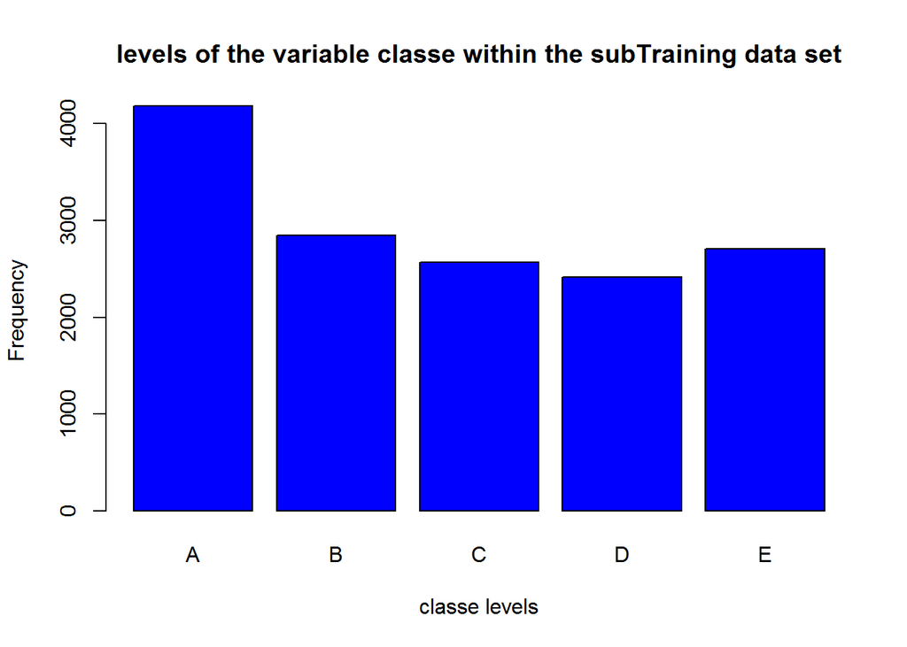

```r
plot(subTraining$classe, col="blue", main="levels of the variable classe within the subTraining data set", xlab="classe levels", ylab="Frequency")
```

The variable “classe” contains 5 levels: A, B, C, D and E. Level A is the most frequent with a little more than 4000 occurrences while level D is the least frequent with about 2500 occurrences.

##### EVALUATION

###### Classification Tree

```r
modFit <- train(classe~ ., data = subTraining, method="rpart")

print(modFit$finalModel, digits=3)
```

```
## n= 14718
##
## node), split, n, loss, yval, (yprob)
##       * denotes terminal node
##
##  1) root 14718 10500 A (0.28 0.19 0.17 0.16 0.18)
##    2) roll_belt< 130 13486  9310 A (0.31 0.21 0.19 0.18 0.11)
##      4) pitch_forearm< -34 1159     8 A (0.99 0.0069 0 0 0) *
##      5) pitch_forearm>=-34 12327  9300 A (0.25 0.23 0.21 0.2 0.12)
##       10) magnet_dumbbell_y< 432 10362  7410 A (0.29 0.18 0.24 0.19 0.11)
##         20) roll_forearm< 122 6420  3780 A (0.41 0.18 0.18 0.17 0.058) *
##         21) roll_forearm>=122 3942  2640 C (0.079 0.18 0.33 0.23 0.18) *
##       11) magnet_dumbbell_y>=432 1965   982 B (0.037 0.5 0.044 0.23 0.19) *
##    3) roll_belt>=130 1232     7 E (0.0057 0 0 0 0.99) *
```

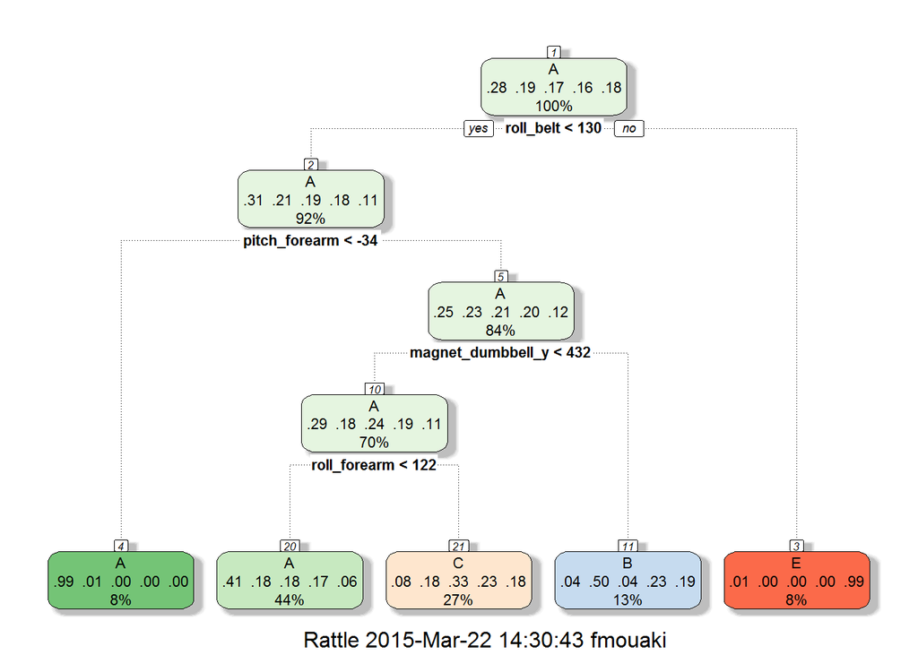

```r
fancyRpartPlot(modFit$finalModel)
```

Run against testing set.

```r
# Run against testing set 1 of 4 with no extra features.
library(caret)
prediction <- predict(modFit, subTesting)
confusionMatrix(prediction, subTesting$classe)
```

```
## Confusion Matrix and Statistics
##
##           Reference
## Prediction    A    B    C    D    E
##          A 1260  383  399  346  140
##          B   35  337   29  155  122
##          C   93  229  427  303  233
##          D    0    0    0    0    0
##          E    7    0    0    0  406
##
## Overall Statistics
##
##                Accuracy : 0.4955
##                  95% CI : (0.4814, 0.5096)
##     No Information Rate : 0.2845
##     P-Value [Acc > NIR] : < 2.2e-16
##
##                   Kappa : 0.3409
##  Mcnemar's Test P-Value : NA
##
## Statistics by Class:
##
##                      Class: A Class: B Class: C Class: D Class: E
## Sensitivity            0.9032  0.35511  0.49942   0.0000  0.45061
## Specificity            0.6386  0.91378  0.78810   1.0000  0.99825
## Pos Pred Value         0.4984  0.49705  0.33230      NaN  0.98305
## Neg Pred Value         0.9432  0.85518  0.88174   0.8361  0.88978
## Prevalence             0.2845  0.19352  0.17435   0.1639  0.18373
## Detection Rate         0.2569  0.06872  0.08707   0.0000  0.08279
## Detection Prevalence   0.5155  0.13825  0.26203   0.0000  0.08422
## Balanced Accuracy      0.7709  0.63445  0.64376   0.5000  0.72443
```

```r
modFit <- train(classe~ ., data = subTraining, preProcess=c("center", "scale"), method="rpart")
prediction <- predict(modFit, subTesting)
confusionMatrix(prediction, subTesting$classe)
```

```
## Confusion Matrix and Statistics
##
##           Reference
## Prediction    A    B    C    D    E
##          A 1260  383  399  346  140
##          B   35  337   29  155  122
##          C   93  229  427  303  233
##          D    0    0    0    0    0
##          E    7    0    0    0  406
##
## Overall Statistics
##
##                Accuracy : 0.4955
##                  95% CI : (0.4814, 0.5096)
##     No Information Rate : 0.2845
##     P-Value [Acc > NIR] : < 2.2e-16
##
##                   Kappa : 0.3409
##  Mcnemar's Test P-Value : NA
##
## Statistics by Class:
##
##                      Class: A Class: B Class: C Class: D Class: E
## Sensitivity            0.9032  0.35511  0.49942   0.0000  0.45061
## Specificity            0.6386  0.91378  0.78810   1.0000  0.99825
## Pos Pred Value         0.4984  0.49705  0.33230      NaN  0.98305
## Neg Pred Value         0.9432  0.85518  0.88174   0.8361  0.88978
## Prevalence             0.2845  0.19352  0.17435   0.1639  0.18373
## Detection Rate         0.2569  0.06872  0.08707   0.0000  0.08279
## Detection Prevalence   0.5155  0.13825  0.26203   0.0000  0.08422
## Balanced Accuracy      0.7709  0.63445  0.64376   0.5000  0.72443
```

###### Random Forest

```r
library(caret)
library(randomForest)

modFit1<-randomForest(classe ~. , data=subTraining, method="class")
#modFit <- train(classe ~ ., data=subTraining, method="rf", prox=TRUE)

#print(modFit$finalModel, digits=3)
prediction<- predict(modFit1, subTesting, type = "class")
confusionMatrix(prediction, subTesting$classe)
```

```
## Confusion Matrix and Statistics
##
##           Reference
## Prediction    A    B    C    D    E
##          A 1394    4    0    0    0
##          B    0  945    8    0    0
##          C    0    0  846    9    1
##          D    0    0    1  795    4
##          E    1    0    0    0  896
##
## Overall Statistics
##
##                Accuracy : 0.9943
##                  95% CI : (0.9918, 0.9962)
##     No Information Rate : 0.2845
##     P-Value [Acc > NIR] : < 2.2e-16
##
##                   Kappa : 0.9928
##  Mcnemar's Test P-Value : NA
##
## Statistics by Class:
##
##                      Class: A Class: B Class: C Class: D Class: E
## Sensitivity            0.9993   0.9958   0.9895   0.9888   0.9945
## Specificity            0.9989   0.9980   0.9975   0.9988   0.9998
## Pos Pred Value         0.9971   0.9916   0.9883   0.9938   0.9989
## Neg Pred Value         0.9997   0.9990   0.9978   0.9978   0.9988
## Prevalence             0.2845   0.1935   0.1743   0.1639   0.1837
## Detection Rate         0.2843   0.1927   0.1725   0.1621   0.1827
## Detection Prevalence   0.2851   0.1943   0.1746   0.1631   0.1829
## Balanced Accuracy      0.9991   0.9969   0.9935   0.9938   0.9971
```

###### Submission

Predict outcome levels on the original Testing data set using Random Forest algorithm

```r
predictfinal <- predict(modFit1, df_testing, type="class")
predictfinal
```

```
##  1  2  3  4  5  6  7  8  9 10 11 12 13 14 15 16 17 18 19 20
##  B  A  B  A  A  E  D  B  A  A  B  C  B  A  E  E  A  B  B  B
## Levels: A B C D E
```

```r
#writing the output
pml_write_files = function(x){
  n = length(x)
  for(i in 1:n){
    filename = paste0("problem_id_",i,".txt")
    write.table(x[i],file=filename,quote=FALSE,row.names=FALSE,col.names=FALSE)
  }
}

pml_write_files(predictfinal)
```